# This is a Title

This is Your Name

9/19/2020

# This is a big title

## This title is a little smaller

### And even smaller

This is normal text

## Intro to the Tidyverse

Let’s do some stuff in the Tidyverse.

First, install and load the packages if you have not already.

## Preparation

Here we load the tidyverse, readxl, and janitor packages. Our focus is on the tidyverse package, but the other two play essential roles in our demo as well.

## Read and Import

```r
# I'm going to create a simple csv file from scratch for demo purposes
write_file(x="a,b,c\n1,2,3\n4,5,NA", path = "file.csv")
# Now let's read it in using 'read.csv()'
tibble1 <- read_csv("file.csv")
tibble1
```

```
## # A tibble: 2 x 3
##       a     b     c
##   <dbl> <dbl> <dbl>
## 1     1     2     3
## 2     4     5    NA
```

```r
# Now let's do 'read_excel()'
# For this part, make sure you have the data set from the provided github and have placed it in the same folder as your project; or include the complete file path to the document
countyHealth <- read_excel("/Users/Theo/Desktop/CADS/2018_County_Health_Rankings_North_Carolina_Data.xls", sheet = 4, skip = 1)
```

```
## * ...
```

```r
countyHealth
```

```
## # A tibble: 101 x 164
##    FIPS  State County `Years of Poten… `95% CI - Low..… `95% CI - High.…
##    <chr> <chr> <chr>             <dbl>            <dbl>            <dbl>
##  1 37000 Nort… <NA>              7281.            7221.            7341.
##  2 37001 Nort… Alama…            7804.            7295.            8314.
##  3 37003 Nort… Alexa…            7334.            6388.            8280.
##  4 37005 Nort… Alleg…            8720.            6504.           10936.
##  5 37007 Nort… Anson            10502.            8977.           12028.
##  6 37009 Nort… Ashe              8310.            6919.            9701.
##  7 37011 Nort… Avery             7297.            5757.            8836.
##  8 37013 Nort… Beauf…            9575.            8458.           10693.
##  9 37015 Nort… Bertie            9781.            7978.           11584.
## 10 37017 Nort… Bladen           11524.           10145.           12903.
## # … with 91 more rows, and 158 more variables: `Z-Score...7` <dbl>, `Years of
## #   Potential Life Lost Rate (Black)` <dbl>, `Years of Potential Life Lost Rate
## #   (Hispanic)` <dbl>, `Years of Potential Life Lost Rate (White)` <dbl>, `%
## #   Fair/Poor` <dbl>, `95% CI - Low...12` <dbl>, `95% CI - High...13` <dbl>,
## #   `Z-Score...14` <dbl>, `Physically Unhealthy Days` <dbl>, `95% CI -
## #   Low...16` <dbl>, `95% CI - High...17` <dbl>, `Z-Score...18` <dbl>,
## #   `Mentally Unhealthy Days` <dbl>, `95% CI - Low...20` <dbl>, `95% CI -
## #   High...21` <dbl>, `Z-Score...22` <dbl>, Unreliable <lgl>, `% LBW` <dbl>,
## #   `95% CI - Low...25` <dbl>, `95% CI - High...26` <dbl>,
## #   `Z-Score...27` <dbl>, `% LBW (Black)` <dbl>, `% LBW (Hispanic)` <dbl>, `%
## #   LBW (White)` <dbl>, `% Smokers` <dbl>, `95% CI - Low...32` <dbl>, `95% CI -
## #   High...33` <dbl>, `Z-Score...34` <dbl>, `% Obese` <dbl>, `95% CI -
## #   Low...36` <dbl>, `95% CI - High...37` <dbl>, `Z-Score...38` <dbl>, `Food
## #   Environment Index` <dbl>, `Z-Score...40` <dbl>, `% Physically
## #   Inactive` <dbl>, `95% CI - Low...42` <dbl>, `95% CI - High...43` <dbl>,
## #   `Z-Score...44` <dbl>, `% With Access` <dbl>, `Z-Score...46` <dbl>, `%
## #   Excessive Drinking` <dbl>, `95% CI - Low...48` <dbl>, `95% CI -
## #   High...49` <dbl>, `Z-Score...50` <dbl>, `# Alcohol-Impaired Driving
## #   Deaths` <dbl>, `# Driving Deaths` <dbl>, `% Alcohol-Impaired` <dbl>, `95%
## #   CI - Low...54` <dbl>, `95% CI - High...55` <dbl>, `Z-Score...56` <dbl>, `#
## #   Chlamydia Cases` <dbl>, `Chlamydia Rate` <dbl>, `Z-Score...59` <dbl>, `Teen
## #   Birth Rate` <dbl>, `95% CI - Low...61` <dbl>, `95% CI - High...62` <dbl>,
## #   `Z-Score...63` <dbl>, `Teen Birth Rate (Black)` <dbl>, `Teen Birth Rate
## #   (Hispanic)` <dbl>, `Teen Birth Rate (White)` <dbl>, `# Uninsured` <dbl>, `%
## #   Uninsured` <dbl>, `95% CI - Low...69` <dbl>, `95% CI - High...70` <dbl>,
## #   `Z-Score...71` <dbl>, `# Primary Care Physicians` <dbl>, `PCP Rate` <dbl>,
## #   `PCP Ratio` <chr>, `Z-Score...75` <dbl>, `# Dentists` <dbl>, `Dentist
## #   Rate` <dbl>, `Dentist Ratio` <chr>, `Z-Score...79` <dbl>, `# Mental Health
## #   Providers` <dbl>, `MHP Rate` <dbl>, `MHP Ratio` <chr>,
## #   `Z-Score...83` <dbl>, `# Medicare Enrollees...84` <dbl>, `Preventable Hosp.
## #   Rate` <dbl>, `95% CI - Low...86` <dbl>, `95% CI - High...87` <dbl>,
## #   `Z-Score...88` <dbl>, `# Diabetics` <dbl>, `% Receiving HbA1c` <dbl>, `95%
## #   CI - Low...91` <dbl>, `95% CI - High...92` <dbl>, `Z-Score...93` <dbl>, `%
## #   Receiving HbA1c (Black)` <dbl>, `% Receiving HbA1c (White)` <dbl>, `#
## #   Medicare Enrollees...96` <dbl>, `% Mammography` <dbl>, `95% CI -
## #   Low...98` <dbl>, `95% CI - High...99` <dbl>, `Z-Score...100` <dbl>, `%
## #   Mammography (Black)` <dbl>, `% Mammography (White)` <dbl>, `Cohort
## #   Size` <dbl>, `Graduation Rate` <dbl>, `Z-Score...105` <dbl>, `# Some
## #   College` <dbl>, …
```

The ‘read_excel()’ command originates from the “readxl” package, so it is important that you have it installed and loaded.

## Tidy

### Tibble, gather(), and spread()

```r
# Let's create a tibble and work with it
tibble2 <- tibble(country = c("x","y","z"), "2010" = c("80","82","108"), "2020" = c("901","289","3160"))
tibble2
```

```
## # A tibble: 3 x 3
##   country `2010` `2020`
##   <chr>   <chr>  <chr>
## 1 x       80     901
## 2 y       82     289
## 3 z       108    3160
```

```r
# Reorganize the data using 'gather()'
table <- gather(tibble2, '2010','2020', key = "year", value = "events")
table
```

```
## # A tibble: 6 x 3
##   country year  events
##   <chr>   <chr> <chr>
## 1 x       2010  80
## 2 y       2010  82
## 3 z       2010  108
## 4 x       2020  901
## 5 y       2020  289
## 6 z       2020  3160
```

```r
# Reverse 'gather()' using 'spread()'
table2 <- spread(table, year, events)
table2
```

```
## # A tibble: 3 x 3
##   country `2010` `2020`
##   <chr>   <chr>  <chr>
## 1 x       80     901
## 2 y       82     289
## 3 z       108    3160
```

In ‘gather()’, the key and value arguments are used to create new columns for the years 2010 and 2020 and for the number of events. ‘spread()’ has a similar argument structure, where we specify which columns in which table we want to condense.

### Working with NAs

```r
# Let's work with another tibble; this one has missing values
table3 <- tibble(x1= c("x","y","z","a","b"), x2 = c(10,NA,NA,32,NA))
table3
```

```
## # A tibble: 5 x 2
##   x1       x2
##   <chr> <dbl>
## 1 x        10
## 2 y        NA
## 3 z        NA
## 4 a        32
## 5 b        NA
```

```r
# How do we work with NAs? Drop them?
table3Drop <- drop_na(table3)
table3Drop
```

```
## # A tibble: 2 x 2
##   x1       x2
##   <chr> <dbl>
## 1 x        10
## 2 a        32
```

```r
# Fill them?
table3Fill <- fill(table3, x2)
table3Fill
```

```
## # A tibble: 5 x 2
##   x1       x2
##   <chr> <dbl>
## 1 x        10
## 2 y        10
## 3 z        10
## 4 a        32
## 5 b        32
```

```r
# Replace them?
table3Replace <- replace_na(table3, replace = list(x2 = 10))
table3Replace
```

```
## # A tibble: 5 x 2
##   x1       x2
##   <chr> <dbl>
## 1 x        10
## 2 y        10
## 3 z        10
## 4 a        32
## 5 b        10
```

Use ‘drop_na()’ with caution, as it will delete entire rows so long as even just one column contains an NA. Dropping NAs from our data set may have the unintended consequence of decreasing our sample size or eliminating other data components that would have otherwise be useful.

### separate() and unite()

```r
# Let's work with yet another tibble here
tibble3 <- tibble(country = c("Afghanistan","Afghanistan","Brazil","Brazil","China","China"), year = c("1999","2000","1999","2000","1999","2000"), rate = c("1/2","1/3","84/105","85/105","34/162","21/162"))
tibble3
```

```
## # A tibble: 6 x 3
##   country     year  rate
##   <chr>       <chr> <chr>
## 1 Afghanistan 1999  1/2
## 2 Afghanistan 2000  1/3
## 3 Brazil      1999  84/105
## 4 Brazil      2000  85/105
## 5 China       1999  34/162
## 6 China       2000  21/162
```

```r
# To separate values within a column, use 'separate()'
table4 <- separate(tibble3, rate, into = c("numerator", "denominator"), sep = "/")
table4
```

```
## # A tibble: 6 x 4
##   country     year  numerator denominator
##   <chr>       <chr> <chr>     <chr>
## 1 Afghanistan 1999  1         2
## 2 Afghanistan 2000  1         3
## 3 Brazil      1999  84        105
## 4 Brazil      2000  85        105
## 5 China       1999  34        162
## 6 China       2000  21        162
```

```r
# We can reverse this using 'unite()' and specify a new separator if we want
unite(table4, numerator, denominator, col = rate, sep = "//")
```

```
## # A tibble: 6 x 3
##   country     year  rate
##   <chr>       <chr> <chr>
## 1 Afghanistan 1999  1//2
## 2 Afghanistan 2000  1//3
## 3 Brazil      1999  84//105
## 4 Brazil      2000  85//105
## 5 China       1999  34//162
## 6 China       2000  21//162
```

‘separate()’ is especially useful if you want to clarify the data you are working with, and even to highlight elements as components of another new column you might wish to create. In this example, we can separate the rate of occurrence into numerator and denominator, then later add a column calculating the rate as a percentage using the numerator and denominator columns.

## Manipulate and Transform

### group_by(), count(), filter(), arrange()

```r
# mtcars is a preloaded data set contained within RStudio that we can work with anytime
mtcars
```

```
##                      mpg cyl  disp  hp drat    wt  qsec vs am gear carb
## Mazda RX4           21.0   6 160.0 110 3.90 2.620 16.46  0  1    4    4
## Mazda RX4 Wag       21.0   6 160.0 110 3.90 2.875 17.02  0  1    4    4
## Datsun 710          22.8   4 108.0  93 3.85 2.320 18.61  1  1    4    1
## Hornet 4 Drive      21.4   6 258.0 110 3.08 3.215 19.44  1  0    3    1
## Hornet Sportabout   18.7   8 360.0 175 3.15 3.440 17.02  0  0    3    2
## Valiant             18.1   6 225.0 105 2.76 3.460 20.22  1  0    3    1
## Duster 360          14.3   8 360.0 245 3.21 3.570 15.84  0  0    3    4
## Merc 240D           24.4   4 146.7  62 3.69 3.190 20.00  1  0    4    2
## Merc 230            22.8   4 140.8  95 3.92 3.150 22.90  1  0    4    2
## Merc 280            19.2   6 167.6 123 3.92 3.440 18.30  1  0    4    4
## Merc 280C           17.8   6 167.6 123 3.92 3.440 18.90  1  0    4    4
## Merc 450SE          16.4   8 275.8 180 3.07 4.070 17.40  0  0    3    3
## Merc 450SL          17.3   8 275.8 180 3.07 3.730 17.60  0  0    3    3
## Merc 450SLC         15.2   8 275.8 180 3.07 3.780 18.00  0  0    3    3
## Cadillac Fleetwood  10.4   8 472.0 205 2.93 5.250 17.98  0  0    3    4
## Lincoln Continental 10.4   8 460.0 215 3.00 5.424 17.82  0  0    3    4
## Chrysler Imperial   14.7   8 440.0 230 3.23 5.345 17.42  0  0    3    4
## Fiat 128            32.4   4  78.7  66 4.08 2.200 19.47  1  1    4    1
## Honda Civic         30.4   4  75.7  52 4.93 1.615 18.52  1  1    4    2
## Toyota Corolla      33.9   4  71.1  65 4.22 1.835 19.90  1  1    4    1
## Toyota Corona       21.5   4 120.1  97 3.70 2.465 20.01  1  0    3    1
## Dodge Challenger    15.5   8 318.0 150 2.76 3.520 16.87  0  0    3    2
## AMC Javelin         15.2   8 304.0 150 3.15 3.435 17.30  0  0    3    2
## Camaro Z28          13.3   8 350.0 245 3.73 3.840 15.41  0  0    3    4
## Pontiac Firebird    19.2   8 400.0 175 3.08 3.845 17.05  0  0    3    2
## Fiat X1-9           27.3   4  79.0  66 4.08 1.935 18.90  1  1    4    1
## Porsche 914-2       26.0   4 120.3  91 4.43 2.140 16.70  0  1    5    2
## Lotus Europa        30.4   4  95.1 113 3.77 1.513 16.90  1  1    5    2
## Ford Pantera L      15.8   8 351.0 264 4.22 3.170 14.50  0  1    5    4
## Ferrari Dino        19.7   6 145.0 175 3.62 2.770 15.50  0  1    5    6
## Maserati Bora       15.0   8 301.0 335 3.54 3.570 14.60  0  1    5    8
## Volvo 142E          21.4   4 121.0 109 4.11 2.780 18.60  1  1    4    2
```

```r
# If we want a smaller glimpse at a data set, we can use 'head()' to get just a peek
head(mtcars)
```

```
##                    mpg cyl disp  hp drat    wt  qsec vs am gear carb
## Mazda RX4         21.0   6  160 110 3.90 2.620 16.46  0  1    4    4
## Mazda RX4 Wag     21.0   6  160 110 3.90 2.875 17.02  0  1    4    4
## Datsun 710        22.8   4  108  93 3.85 2.320 18.61  1  1    4    1
## Hornet 4 Drive    21.4   6  258 110 3.08 3.215 19.44  1  0    3    1
## Hornet Sportabout 18.7   8  360 175 3.15 3.440 17.02  0  0    3    2
## Valiant           18.1   6  225 105 2.76 3.460 20.22  1  0    3    1
```

```r
# What does 'group_by()' do? The argument "cyl" here is a column from mtcars. This is also our first example of piping!
mtcars %>% group_by(cyl)
```

```
## # A tibble: 32 x 11
## # Groups:   cyl [3]
##      mpg   cyl  disp    hp  drat    wt  qsec    vs    am  gear  carb
##    <dbl> <dbl> <dbl> <dbl> <dbl> <dbl> <dbl> <dbl> <dbl> <dbl> <dbl>
##  1  21       6  160    110  3.9   2.62  16.5     0     1     4     4
##  2  21       6  160    110  3.9   2.88  17.0     0     1     4     4
##  3  22.8     4  108     93  3.85  2.32  18.6     1     1     4     1
##  4  21.4     6  258    110  3.08  3.22  19.4     1     0     3     1
##  5  18.7     8  360    175  3.15  3.44  17.0     0     0     3     2
##  6  18.1     6  225    105  2.76  3.46  20.2     1     0     3     1
##  7  14.3     8  360    245  3.21  3.57  15.8     0     0     3     4
##  8  24.4     4  147.    62  3.69  3.19  20       1     0     4     2
##  9  22.8     4  141.    95  3.92  3.15  22.9     1     0     4     2
## 10  19.2     6  168.   123  3.92  3.44  18.3     1     0     4     4
## # … with 22 more rows
```

```r
# What if we want to count how many rows are in the "cyl" column?
mtcars %>% group_by(cyl) %>% count()   # here we've simply extended our pipe by adding another "%>%" instead of using another line to do so
```

```
## # A tibble: 3 x 2
## # Groups:   cyl [3]
##     cyl     n
##   <dbl> <int>
## 1     4    11
## 2     6     7
## 3     8    14
```

```r
# I only want cars with a horsepower greater than 200 and engines with 6 or more cylinders. How would I view a table of that?
mtcars %>% filter(cyl >= 6 & hp > 200)
```

```
##                      mpg cyl disp  hp drat    wt  qsec vs am gear carb
## Duster 360          14.3   8  360 245 3.21 3.570 15.84  0  0    3    4
## Cadillac Fleetwood  10.4   8  472 205 2.93 5.250 17.98  0  0    3    4
## Lincoln Continental 10.4   8  460 215 3.00 5.424 17.82  0  0    3    4
## Chrysler Imperial   14.7   8  440 230 3.23 5.345 17.42  0  0    3    4
## Camaro Z28          13.3   8  350 245 3.73 3.840 15.41  0  0    3    4
## Ford Pantera L      15.8   8  351 264 4.22 3.170 14.50  0  1    5    4
## Maserati Bora       15.0   8  301 335 3.54 3.570 14.60  0  1    5    8
```

```r
# Now I want to view the table in decreasing order to find out the best and worst cars in that category
mtcars %>% arrange(desc(mpg))   # arrange will default to arrangiing your query in ascending order unless you specify descending
```

```
##                      mpg cyl  disp  hp drat    wt  qsec vs am gear carb
## Toyota Corolla      33.9   4  71.1  65 4.22 1.835 19.90  1  1    4    1
## Fiat 128            32.4   4  78.7  66 4.08 2.200 19.47  1  1    4    1
## Honda Civic         30.4   4  75.7  52 4.93 1.615 18.52  1  1    4    2
## Lotus Europa        30.4   4  95.1 113 3.77 1.513 16.90  1  1    5    2
## Fiat X1-9           27.3   4  79.0  66 4.08 1.935 18.90  1  1    4    1
## Porsche 914-2       26.0   4 120.3  91 4.43 2.140 16.70  0  1    5    2
## Merc 240D           24.4   4 146.7  62 3.69 3.190 20.00  1  0    4    2
## Datsun 710          22.8   4 108.0  93 3.85 2.320 18.61  1  1    4    1
## Merc 230            22.8   4 140.8  95 3.92 3.150 22.90  1  0    4    2
## Toyota Corona       21.5   4 120.1  97 3.70 2.465 20.01  1  0    3    1
## Hornet 4 Drive      21.4   6 258.0 110 3.08 3.215 19.44  1  0    3    1
## Volvo 142E          21.4   4 121.0 109 4.11 2.780 18.60  1  1    4    2
## Mazda RX4           21.0   6 160.0 110 3.90 2.620 16.46  0  1    4    4
## Mazda RX4 Wag       21.0   6 160.0 110 3.90 2.875 17.02  0  1    4    4
## Ferrari Dino        19.7   6 145.0 175 3.62 2.770 15.50  0  1    5    6
## Merc 280            19.2   6 167.6 123 3.92 3.440 18.30  1  0    4    4
## Pontiac Firebird    19.2   8 400.0 175 3.08 3.845 17.05  0  0    3    2
## Hornet Sportabout   18.7   8 360.0 175 3.15 3.440 17.02  0  0    3    2
## Valiant             18.1   6 225.0 105 2.76 3.460 20.22  1  0    3    1
## Merc 280C           17.8   6 167.6 123 3.92 3.440 18.90  1  0    4    4
## Merc 450SL          17.3   8 275.8 180 3.07 3.730 17.60  0  0    3    3
## Merc 450SE          16.4   8 275.8 180 3.07 4.070 17.40  0  0    3    3
## Ford Pantera L      15.8   8 351.0 264 4.22 3.170 14.50  0  1    5    4
## Dodge Challenger    15.5   8 318.0 150 2.76 3.520 16.87  0  0    3    2
## Merc 450SLC         15.2   8 275.8 180 3.07 3.780 18.00  0  0    3    3
## AMC Javelin         15.2   8 304.0 150 3.15 3.435 17.30  0  0    3    2
## Maserati Bora       15.0   8 301.0 335 3.54 3.570 14.60  0  1    5    8
## Chrysler Imperial   14.7   8 440.0 230 3.23 5.345 17.42  0  0    3    4
## Duster 360          14.3   8 360.0 245 3.21 3.570 15.84  0  0    3    4
## Camaro Z28          13.3   8 350.0 245 3.73 3.840 15.41  0  0    3    4
## Cadillac Fleetwood  10.4   8 472.0 205 2.93 5.250 17.98  0  0    3    4
## Lincoln Continental 10.4   8 460.0 215 3.00 5.424 17.82  0  0    3    4
```

As noted in the comments above, ‘arrange()’ will automatically default to arranging your query in ascending order unless you specifically tell it to arrange it in descending order.

‘group_by()’, ‘filter()’, and ‘arrange()’ are great commands to focus in on certain parts of the data. These commands allow you to do so without actually manipulating the data set in any manner, meaning none of the rest of the data is lost or deleted. The upcoming commands, however, will minipulate the data set accordingly.

### select(), mutate(), renaming, and basic joining

```r
# 'select()' selects columns of one's choice from the data set and displays only those columns
mtcars %>% select(qsec, hp)
```

```
##                      qsec  hp
## Mazda RX4           16.46 110
## Mazda RX4 Wag       17.02 110
## Datsun 710          18.61  93
## Hornet 4 Drive      19.44 110
## Hornet Sportabout   17.02 175
## Valiant             20.22 105
## Duster 360          15.84 245
## Merc 240D           20.00  62
## Merc 230            22.90  95
## Merc 280            18.30 123
## Merc 280C           18.90 123
## Merc 450SE          17.40 180
## Merc 450SL          17.60 180
## Merc 450SLC         18.00 180
## Cadillac Fleetwood  17.98 205
## Lincoln Continental 17.82 215
## Chrysler Imperial   17.42 230
## Fiat 128            19.47  66
## Honda Civic         18.52  52
## Toyota Corolla      19.90  65
## Toyota Corona       20.01  97
## Dodge Challenger    16.87 150
## AMC Javelin         17.30 150
## Camaro Z28          15.41 245
## Pontiac Firebird    17.05 175
## Fiat X1-9           18.90  66
## Porsche 914-2       16.70  91
## Lotus Europa        16.90 113
## Ford Pantera L      14.50 264
## Ferrari Dino        15.50 175
## Maserati Bora       14.60 335
## Volvo 142E          18.60 109
```

```r
# We can also specify which columns to not include, rather than type a bunch of columns that we do want
mtcars %>% select(-mpg, -cyl, -disp, -hp)
```

```
##                     drat    wt  qsec vs am gear carb
## Mazda RX4           3.90 2.620 16.46  0  1    4    4
## Mazda RX4 Wag       3.90 2.875 17.02  0  1    4    4
## Datsun 710          3.85 2.320 18.61  1  1    4    1
## Hornet 4 Drive      3.08 3.215 19.44  1  0    3    1
## Hornet Sportabout   3.15 3.440 17.02  0  0    3    2
## Valiant             2.76 3.460 20.22  1  0    3    1
## Duster 360          3.21 3.570 15.84  0  0    3    4
## Merc 240D           3.69 3.190 20.00  1  0    4    2
## Merc 230            3.92 3.150 22.90  1  0    4    2
## Merc 280            3.92 3.440 18.30  1  0    4    4
## Merc 280C           3.92 3.440 18.90  1  0    4    4
## Merc 450SE          3.07 4.070 17.40  0  0    3    3
## Merc 450SL          3.07 3.730 17.60  0  0    3    3
## Merc 450SLC         3.07 3.780 18.00  0  0    3    3
## Cadillac Fleetwood  2.93 5.250 17.98  0  0    3    4
## Lincoln Continental 3.00 5.424 17.82  0  0    3    4
## Chrysler Imperial   3.23 5.345 17.42  0  0    3    4
## Fiat 128            4.08 2.200 19.47  1  1    4    1
## Honda Civic         4.93 1.615 18.52  1  1    4    2
## Toyota Corolla      4.22 1.835 19.90  1  1    4    1
## Toyota Corona       3.70 2.465 20.01  1  0    3    1
## Dodge Challenger    2.76 3.520 16.87  0  0    3    2
## AMC Javelin         3.15 3.435 17.30  0  0    3    2
## Camaro Z28          3.73 3.840 15.41  0  0    3    4
## Pontiac Firebird    3.08 3.845 17.05  0  0    3    2
## Fiat X1-9           4.08 1.935 18.90  1  1    4    1
## Porsche 914-2       4.43 2.140 16.70  0  1    5    2
## Lotus Europa        3.77 1.513 16.90  1  1    5    2
## Ford Pantera L      4.22 3.170 14.50  0  1    5    4
## Ferrari Dino        3.62 2.770 15.50  0  1    5    6
## Maserati Bora       3.54 3.570 14.60  0  1    5    8
## Volvo 142E          4.11 2.780 18.60  1  1    4    2
```

```r
# 'mutate()' allows you to create columns of your on choosing absent from the original data set; perhaps you want a column specifically for horsepower per ton?
mtcars %>% mutate(hpPerTon = hp/wt)
```

```
##     mpg cyl  disp  hp drat    wt  qsec vs am gear carb hpPerTon
## 1  21.0   6 160.0 110 3.90 2.620 16.46  0  1    4    4 41.98473
## 2  21.0   6 160.0 110 3.90 2.875 17.02  0  1    4    4 38.26087
## 3  22.8   4 108.0  93 3.85 2.320 18.61  1  1    4    1 40.08621
## 4  21.4   6 258.0 110 3.08 3.215 19.44  1  0    3    1 34.21462
## 5  18.7   8 360.0 175 3.15 3.440 17.02  0  0    3    2 50.87209
## 6  18.1   6 225.0 105 2.76 3.460 20.22  1  0    3    1 30.34682
## 7  14.3   8 360.0 245 3.21 3.570 15.84  0  0    3    4 68.62745
## 8  24.4   4 146.7  62 3.69 3.190 20.00  1  0    4    2 19.43574
## 9  22.8   4 140.8  95 3.92 3.150 22.90  1  0    4    2 30.15873
## 10 19.2   6 167.6 123 3.92 3.440 18.30  1  0    4    4 35.75581
## 11 17.8   6 167.6 123 3.92 3.440 18.90  1  0    4    4 35.75581
## 12 16.4   8 275.8 180 3.07 4.070 17.40  0  0    3    3 44.22604
## 13 17.3   8 275.8 180 3.07 3.730 17.60  0  0    3    3 48.25737
## 14 15.2   8 275.8 180 3.07 3.780 18.00  0  0    3    3 47.61905
```

[output cut: 18 more lines]

```r
# Names are finicky; sometimes the data set has ugly preset names and other times people prefer reading camel case (variableName) or snake case (variable_name)
# How do we change naming conventions here?
# We can rename them entirely
mtcarsHP <- mtcars %>% rename(horsepower = hp)

# Sometimes you have two data separate data sets you want to work with. It's inefficient and complicated to work with them separately, so we can join them to simplify things
mtcars1 <- rownames_to_column(mtcars, var="car_model") %>% select(-qsec, -disp, -cyl)   # making a data table from mtcars without qsec, disp, and cyl columns
mtcars2 <- rownames_to_column(mtcars, var = "car_model") %>% select(-mpg, -hp, -wt)   # making a data table from mtcars without mpg, hp, and wt columns
mtcarsJoin  <- left_join(mtcars1, mtcars2, by="car_model")   # join them together
head(mtcars1)
```

```
##           car_model  mpg  hp drat    wt vs am gear carb
## 1         Mazda RX4 21.0 110 3.90 2.620  0  1    4    4
## 2     Mazda RX4 Wag 21.0 110 3.90 2.875  0  1    4    4
## 3        Datsun 710 22.8  93 3.85 2.320  1  1    4    1
## 4    Hornet 4 Drive 21.4 110 3.08 3.215  1  0    3    1
## 5 Hornet Sportabout 18.7 175 3.15 3.440  0  0    3    2
## 6           Valiant 18.1 105 2.76 3.460  1  0    3    1
```

```r
head(mtcars2)
```

```
##           car_model cyl disp drat  qsec vs am gear carb
## 1         Mazda RX4   6  160 3.90 16.46  0  1    4    4
## 2     Mazda RX4 Wag   6  160 3.90 17.02  0  1    4    4
## 3        Datsun 710   4  108 3.85 18.61  1  1    4    1
## 4    Hornet 4 Drive   6  258 3.08 19.44  1  0    3    1
## 5 Hornet Sportabout   8  360 3.15 17.02  0  0    3    2
## 6           Valiant   6  225 2.76 20.22  1  0    3    1
```

```r
head(mtcarsJoin)
```

```
##           car_model  mpg  hp drat.x    wt vs.x am.x gear.x carb.x cyl disp
## 1         Mazda RX4 21.0 110   3.90 2.620    0    1      4      4   6  160
## 2     Mazda RX4 Wag 21.0 110   3.90 2.875    0    1      4      4   6  160
## 3        Datsun 710 22.8  93   3.85 2.320    1    1      4      1   4  108
## 4    Hornet 4 Drive 21.4 110   3.08 3.215    1    0      3      1   6  258
## 5 Hornet Sportabout 18.7 175   3.15 3.440    0    0      3      2   8  360
## 6           Valiant 18.1 105   2.76 3.460    1    0      3      1   6  225
##   drat.y  qsec vs.y am.y gear.y carb.y
## 1   3.90 16.46    0    1      4      4
## 2   3.90 17.02    0    1      4      4
## 3   3.85 18.61    1    1      4      1
## 4   3.08 19.44    1    0      3      1
## 5   3.15 17.02    0    0      3      2
## 6   2.76 20.22    1    0      3      1
```

The argument structure for ‘mutate()’ specifies the new column name first (hpPerTon) followed by what the column is comprised of the hp (horsepower) column divided by the wt (weight) column.

You should only join different data sets/tables together if they have a shared element between them (say if both have a column for car names). Otherwise, you can use ‘mutate()’ to create those shared columns if need be. Another thing to note is that left joins can easily delete large amounts of data if done improperly. The order in which you specify the tables to join is critical; in the example above, we are joinig mtcars2 to mtcars1. That means everything shared in the mtcars2 data set is being added to the mtcars1 data set. If the mtcars1 dataset does not contain a car present in mtcars2, then the join will delete that car data. Conversely, if mtcars1 contains a car that mtcars2 doesn’t then joining will leave that car with missing data from mtcars2.

### Putting it All Together

```r
# Let's work with our county health data set now!
countyVariables <- countyHealth %>% select(c("County", "Mentally Unhealthy Days", "Average Daily PM2.5", "Food Environment Index")) %>% rename("Air Quality Score Rating" = "Average Daily PM2.5") %>% rename("County Name" = "County") %>% clean_names(case = "snake") %>% drop_na()
head(countyVariables)
```

```
## # A tibble: 6 x 4
##   county_name mentally_unhealthy_da… air_quality_score_rat… food_environment_in…
##   <chr>                        <dbl>                  <dbl>                <dbl>
## 1 Alamance                      4.28                    9.3                  7.1
## 2 Alexander                     4.20                    9.6                  8
## 3 Alleghany                     4.26                    8.3                  8.2
## 4 Anson                         4.31                    9.5                  6.3
## 5 Ashe                          4.12                    8.2                  8
## 6 Avery                         4.15                    8.3                  8.3
```

The code chunk above may look complicated, but its easy to read if we separate it into smaller parts. At the very beginning of this document, we read in an excel file and called it “countyHealth”. We are now selecting certain variables from that data set (County, Mentally Unhealthy Days, Average Daily PM2.5, Food Environment Index), renaming some of them (Average Daily PM2.5 is renamed to Air Quality Score Rating) and cleaning some names to fit snake case (variable_name).

‘clean_names()’ comes from the “janitor” package we loaded in earlier; it simply adjusts the column names to fit a certain case (camel, snake, etc.).

## Visualize

So far, we’ve read in our data, tidied it up, and transformed it. Now it is time to visualize it and actually see it! Below are just a few simple plots that we can create; there are plenty more complicated ones that I haven’t touched here.

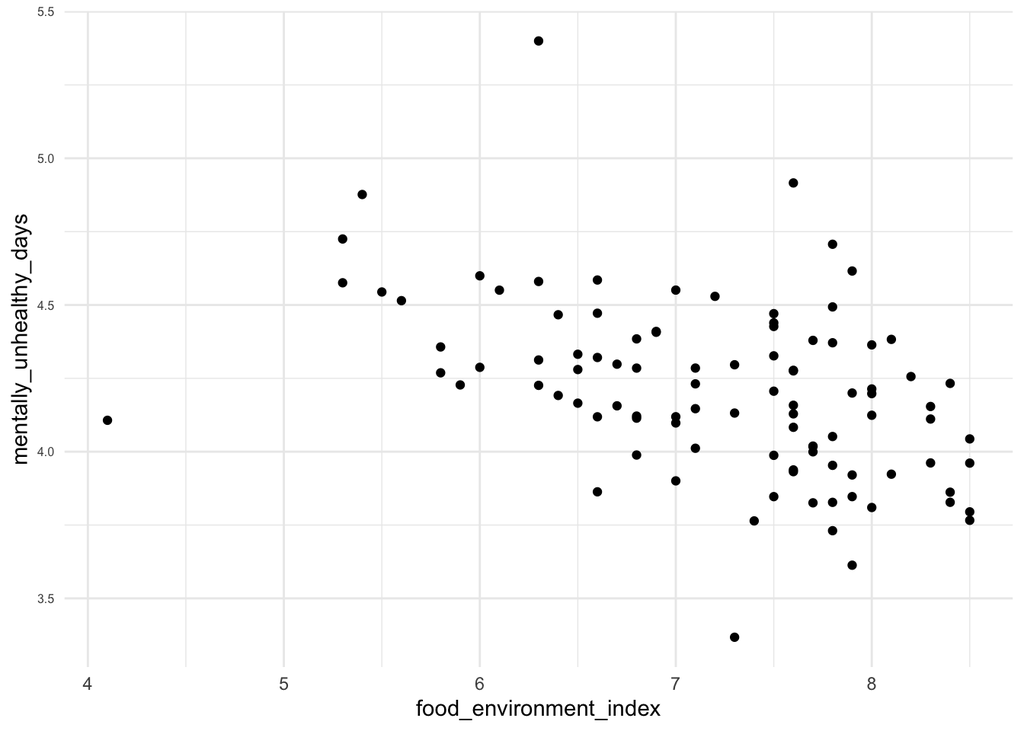

```r
# We can make a dazzling array of plots if we wish. Here's a simple scatter plot
countyVariables %>% ggplot(aes(x = food_environment_index, y = mentally_unhealthy_days)) + geom_point() +  theme_minimal() + theme(axis.text.y = element_text(size = 6))
```

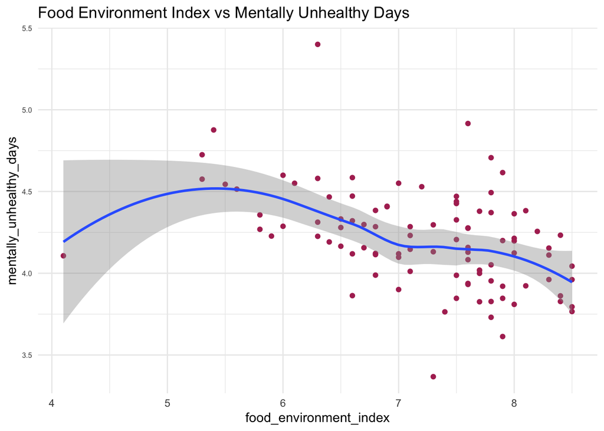

```r
# Add in some regression, color, and titling
countyVariables %>% ggplot(aes(x = food_environment_index, y = mentally_unhealthy_days)) + geom_point(color = "maroon") + geom_smooth() + labs(title = "Food Environment Index vs Mentally Unhealthy Days") + theme_minimal() + theme(axis.text.y = element_text(size = 6))
```

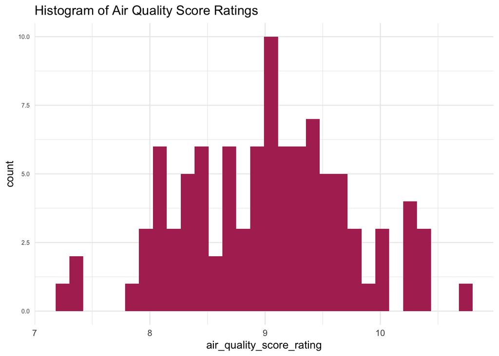

```r
# Maybe we want to see a histogram?
countyVariables %>% ggplot(aes(x = air_quality_score_rating)) + geom_histogram(fill = "maroon") + labs(title = "Histogram of Air Quality Score Ratings") + theme_minimal() + theme(axis.text.y = element_text(size = 6))
```

Tidyverse includes the “ggplot2” package, which is a huge improvement over R’s basic graphics. We use the command ‘ggplot()’ and numerous following arguments to create a plot according to our specifications. These types of plots are highly customizable, ranging from type of plot to color, theme, layout, titles, scales, and even interactivity.

Here are the main components you should focus on:

“aes(x=,y=)” is an argument where you input your variables from the data set. Note that for histograms, you only need “aes(x=)” because you only want to show counts for one variable, not two.

“geom_TYPE()” specifies what type of plot you want to make. The first two plots use “geom_point()”, which denotes a scatter plot. “geom_histogram()” similarly denotes a histogram. There are various other types of plots such as “geom_line()”, “geom_bar()”, and “geom_path()” to name a few. You can even specify certain colors within “geom_TYPE()” to give your visual a little splash of color.

“labs()” is where you input any axis labels or titles for your plots. Make sure to include your titles within quotation marks!

“geom_smooth()” fits a basic regression line to scatter plots.

“theme_minimal()” and “theme()” simply change the appearance of certain parts of the plot; these arguments can be played around with to your heart’s content.